# Domaći zadatak 2 — Tri hipoteze

### Post-hoc analiza: Dunn test (Bonferroni korekcija)

> **Šta je post-hoc i zašto Dunn test?** *Post-hoc* (lat. “nakon ovoga”) je naziv za testove koji se rade **posle** glavnog testa kada on pokaže značajnost. Kruskal-Wallis kaže samo da su neke grupe različite, ali ne koje. Dunn test zatim poredi svaki par kategorija (8 kategorija = 28 parova: Spicy vs Fruity, Spicy vs Fresh, Woody vs Citrus…). Bonferroni korekcija postoji jer kada radimo 28 testova odjednom, statistički šum se akumulira — pa se prag za “značajno” strože postavlja da bismo izbegli lažne pozitivne rezultate.

```r
set.seed(42)
dunn_h1 <- parfumo_h1 %>%
  dunn_test(Rating_Value ~ first_accord, p.adjust.method = "bonferroni")

# Sažetak: koliko parova se statistički značajno razlikuje
dunn_h1 %>%
  filter(p.adj < 0.05) %>%
  select(group1, group2, statistic, p.adj) %>%
  arrange(p.adj) %>%
  slice_head(n = 10) %>%
  mutate(p.adj = ifelse(p.adj < 0.0001, "< 0.0001", as.character(round(p.adj, 4)))) %>%
  kable(
    col.names = c("Grupa 1", "Grupa 2", "Z statistika", "p (adj., Bonf.)"),
    caption = "Top 10 statistički značajnih parova — Dunn test sa Bonferroni korekcijom"
  ) %>%
  kable_styling(bootstrap_options = c("striped","hover","condensed"))
```

Top 10 statistički značajnih parova — Dunn test sa Bonferroni korekcijom

| Grupa 1 | Grupa 2 | Z statistika | p (adj., Bonf.) |
| --- | --- | --- | --- |
| Fresh | Spicy | 24.52006 | < 0.0001 |
| Fruity | Spicy | 23.79569 | < 0.0001 |
| Fresh | Woody | 18.33105 | < 0.0001 |
| Fruity | Woody | 18.23672 | < 0.0001 |
| Fresh | Sweet | 15.77322 | < 0.0001 |
| Fruity | Sweet | 15.73059 | < 0.0001 |
| Floral | Spicy | 15.71970 | < 0.0001 |
| Fruity | Floral | 13.14222 | < 0.0001 |
| Fresh | Floral | 13.07610 | < 0.0001 |
| Fruity | Green | 12.51221 | < 0.0001 |

**Komentar:** Tabela prikazuje samo statistički značajne parove (p < 0.05 nakon korekcije). Parovi sa najmanjim p-vrednostima predstavljaju najsigurnije razlike — npr. Spicy vs Fruity i Spicy vs Fresh su parovi gde su razlike u ocenama najizraženije i najteže objašnjive slučajnošću.

### Vizualizacija rezultata

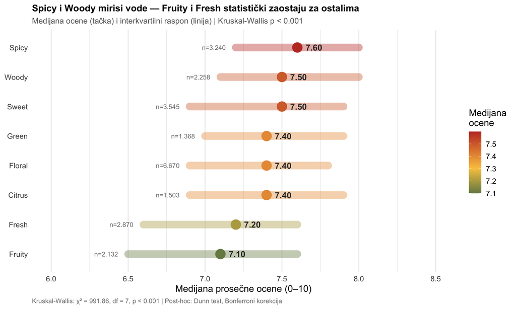

```r
medijane_h1 <- parfumo_h1 %>%
  group_by(first_accord) %>%
  summarise(
    n       = n(),
    med     = median(Rating_Value),
    q1      = quantile(Rating_Value, 0.25),
    q3      = quantile(Rating_Value, 0.75),
    .groups = "drop"
  ) %>%
  mutate(first_accord = fct_reorder(first_accord, med))

ggplot(medijane_h1, aes(x = med, y = first_accord)) +
  geom_segment(
    aes(x = q1, xend = q3, yend = first_accord, color = med),
    linewidth = 5, alpha = 0.4, lineend = "round"
  ) +
  geom_point(aes(color = med), size = 6) +
  geom_text(
    aes(label = sprintf("%.2f", med)),
    hjust = -0.5, fontface = "bold", size = 4.2, color = "gray20"
  ) +
  geom_text(
    aes(x = q1 - 0.05, label = paste0("n=", format(n, big.mark="."))),
    hjust = 1.1, size = 3.2, color = "gray50"
  ) +
  scale_color_gradient2(
    low = "#2d6a4f", mid = "#f9c74f", high = "#c0392b",
    midpoint = 7.3, name = "Medijana\nocene"
  ) +
  scale_x_continuous(limits = c(6.0, 8.5), breaks = seq(6, 8.5, 0.5)) +
  labs(
    title    = "Spicy i Woody mirisi vode — Fruity i Fresh statistički zaostaju za ostalima",
    subtitle = "Medijana ocene (tačka) i interkvartilni raspon (linija) | Kruskal-Wallis p < 0.001",
    x        = "Medijana prosečne ocene (0–10)",
    y        = NULL,
    caption  = paste0(
      "Kruskal-Wallis: χ² = ", round(kruskal_h1$statistic, 2),
      ", df = ", kruskal_h1$parameter, ", p < 0.001",
      " | Post-hoc: Dunn test, Bonferroni korekcija"
    )
  ) +
  theme_minimal(base_size = 13) +
  theme(
    plot.title    = element_text(face = "bold", size = 13, lineheight = 1.2),
    plot.subtitle = element_text(color = "gray40", size = 11),
    plot.caption  = element_text(color = "gray50", size = 9, hjust = 0),
    panel.grid.major.y = element_blank(),
    legend.position = "right"
  )
```

**Interpretacija:** Postoji statistički veoma značajna razlika u ocenama između aromatskih kategorija (p < 0.001). Začinski (Spicy) i drveni (Woody) mirisi dobijaju sistematski više ocene od voćnih (Fruity) i svežih (Fresh). Entuzijasti Parfumo zajednice favorizuju kompleksne, “teže” mirisne profile karakteristične za niche i prestiž brendove — naspram lakih, masovnih kategorija.

> **Zaključak:** Na Parfumo platformi, začinski i drveni mirisi konzistentno dobijaju bolje ocene od voćnih i svežih — što govori da ova zajednica ceni teže, složenije mirise više od lakih i svežih.

## 3.2 Pitanje 2: Popularnost ≠ kvalitet — ko su “hidden gems” Parfumo zajednice?

```r
# Prebrojavanje nota po parfemu (broj zareza + 1 za svaki neprazan sloj)
count_notes <- function(x) {
  ifelse(is.na(x) | str_trim(x) == "", 0L, str_count(x, ",") + 1L)
}

# Filtriramo na minimum 10 glasova (uklanjamo šum od jedne-dve ocene)
parfumo_h2 <- parfumo %>%
  filter(!is.na(Rating_Value), !is.na(Rating_Count), Rating_Count >= 10) %>%
  mutate(
    note_count = count_notes(Top_Notes) +
                 count_notes(Middle_Notes) +
                 count_notes(Base_Notes),
    first_accord_h2 = ifelse(
      first_accord %in% top_accords, first_accord, "Ostalo"
    ) %>% replace_na("Ostalo")
  )

# Pragovi za zone — percentilni, ne ad-hoc
q25_votes <- quantile(parfumo_h2$Rating_Count, 0.25)
q75_votes <- quantile(parfumo_h2$Rating_Count, 0.75)
p80_rating <- quantile(parfumo_h2$Rating_Value, 0.80)
med_rating  <- median(parfumo_h2$Rating_Value)

parfumo_h2 <- parfumo_h2 %>%
  mutate(
    zona = case_when(
      Rating_Value >= p80_rating & Rating_Count <= q25_votes ~ "Hidden gem",
      Rating_Value >= p80_rating & Rating_Count >= q75_votes ~ "Zasluženo popularan",
      Rating_Value < med_rating  & Rating_Count >= q75_votes ~ "Overrated",
      TRUE ~ "Prosek"
    )
  )
```

### Motivaciona vizualizacija i provera pretpostavki

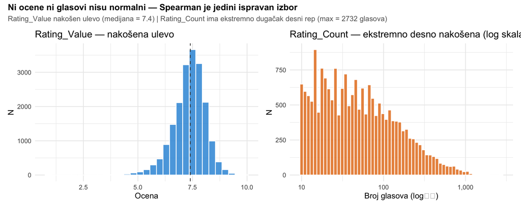

```r
p_r <- ggplot(parfumo_h2, aes(x = Rating_Value)) +
  geom_histogram(binwidth = 0.3, fill = "#3498db", color = "white", alpha = 0.85) +
  geom_vline(xintercept = median(parfumo_h2$Rating_Value),
             linetype = "dashed", color = "gray30") +
  labs(title = "Rating_Value — nakošena ulevo",
       x = "Ocena", y = "N") +
  theme_minimal(base_size = 11)

p_v <- ggplot(parfumo_h2, aes(x = Rating_Count)) +
  geom_histogram(bins = 60, fill = "#e67e22", color = "white", alpha = 0.85) +
  scale_x_log10(labels = comma) +
  labs(title = "Rating_Count — ekstremno desno nakošena (log skala)",
       x = "Broj glasova (log₁₀)", y = "N") +
  theme_minimal(base_size = 11)

(p_r + p_v) +
  plot_annotation(
    title    = "Ni ocene ni glasovi nisu normalni — Spearman je jedini ispravan izbor",
    subtitle = paste0(
      "Rating_Value nakošen ulevo (medijana = ", round(med_rating, 2),
      ") | Rating_Count ima ekstremno dugačak desni rep (max = ",
      max(parfumo_h2$Rating_Count), " glasova)"
    ),
    theme = theme(
      plot.title    = element_text(face = "bold", size = 12),
      plot.subtitle = element_text(color = "gray40", size = 10)
    )
  )
```

**Obrazloženje izbora Spearmana:** `Rating_Value` je nakošen ulevo, a `Rating_Count` ima ekstremno desno-nakošenu raspodelu sa outlajrima (do 2732 glasova). Pearsonova korelacija zahteva normalnost i linearnost — ovde ni jedno ne važi. Kendall-τ je konzervativniji i sporiji na velikom skupu. **Spearmanova korelacija** radi sa rangovima, robusna je na outlajere i nelinearne monotone veze.

**Komentar:** Oba histograma potvrđuju da nijedna od varijabli nije normalno raspoređena. `Rating_Value` je nakošen ulevo — većina parfema ima relativno visoke ocene, što je tipično za platforme gde korisnici ocenjuju samo ono što su svesno izabrali i kupili. `Rating_Count` ima ekstremno dugačak desni rep — mali broj parfema ima stotine ili hiljade glasova, dok ih ogromna većina ima samo nekoliko desetina.

### Spearman korelacija

```r
cor_h2 <- cor.test(
  parfumo_h2$Rating_Count,
  parfumo_h2$Rating_Value,
  method = "spearman"
)
print(cor_h2)
```

```
##
##  Spearman's rank correlation rho
##
## data:  parfumo_h2$Rating_Count and parfumo_h2$Rating_Value
## S = 1.0564e+12, p-value < 2.2e-16
## alternative hypothesis: true rho is not equal to 0
## sample estimates:
##       rho
## 0.1438746
```

**Komentar:** Spearmanova korelacija između broja glasova i ocene je slaba — što znači da popularnost i kvalitet (po mišljenju zajednice) ne idu nužno ruku pod ruku. LOESS kriva na scatter plotu pokazuje tek blagi pozitivni nagib, a raspršenost tačaka je velika na svim nivoima popularnosti.